# CS379_U4_Anthony_Morrison

```
CART GINI

Anthony Morrison
```

This code analyzes the mushroom classification dataset using a Classification and Regression Tree (CART). The data is well suited for a classification solution and splitting. I thought the idea of analyzing mushroom data to see if they were edible was interesting. The CART algorithm is used since the data for mushrooms as either edible or not edible is categorical. It is also good at identifying which features are important for decision making and which will have the most impact on predictions. We used the Gini impurity approach to splitting the tree.

```python
# import numpy to deal with data
import numpy as np
# import pandas to work with data sets
import pandas as pd
# import pyplot to plot data
import matplotlib.pyplot as plt
# import seaborn for visualizations
import seaborn  as sns

from sklearn.preprocessing import LabelEncoder

from sklearn.model_selection import train_test_split

from sklearn.tree import DecisionTreeClassifier
from sklearn import tree

from sklearn.metrics import accuracy_score
```

```python
# Read in the dataset
ds = pd.read_csv('mushrooms.csv')
```

```python
# Look at the first 5 rows
ds.head()
```

|  | class | cap-shape | cap-surface | cap-color | bruises | odor | gill-attachment | gill-spacing | gill-size | gill-color | ... | stalk-surface-below-ring | stalk-color-above-ring | stalk-color-below-ring | veil-type | veil-color | ring-number | ring-type | spore-print-color | population | habitat |
| --- | --- | --- | --- | --- | --- | --- | --- | --- | --- | --- | --- | --- | --- | --- | --- | --- | --- | --- | --- | --- | --- |
| 0 | p | x | s | n | t | p | f | c | n | k | ... | s | w | w | p | w | o | p | k | s | u |
| 1 | e | x | s | y | t | a | f | c | b | k | ... | s | w | w | p | w | o | p | n | n | g |
| 2 | e | b | s | w | t | l | f | c | b | n | ... | s | w | w | p | w | o | p | n | n | m |
| 3 | p | x | y | w | t | p | f | c | n | n | ... | s | w | w | p | w | o | p | k | s | u |
| 4 | e | x | s | g | f | n | f | w | b | k | ... | s | w | w | p | w | o | e | n | a | g |

5 rows × 23 columns

```python
# check for null values
ds.isnull().sum().sum()
```

```
0
```

# Edible or not

For this we are looking at the column labeled 'class' which represents edible 'e' or poisonous 'p' mushroooms.

```python
# look at the unique values for 'class'
ds['class'].unique()
```

```
array(['p', 'e'], dtype=object)
```

# Looking at the data

The data is already pretty well organized and defined. I believe the correct term for the data in this set is that it is very homogeneous.

```python
ds.info()
```

```
<class 'pandas.core.frame.DataFrame'>
RangeIndex: 8124 entries, 0 to 8123
Data columns (total 23 columns):
 #   Column                    Non-Null Count  Dtype
---  ------                    --------------  -----
 0   class                     8124 non-null   object
 1   cap-shape                 8124 non-null   object
 2   cap-surface               8124 non-null   object
 3   cap-color                 8124 non-null   object
 4   bruises                   8124 non-null   object
 5   odor                      8124 non-null   object
 6   gill-attachment           8124 non-null   object
 7   gill-spacing              8124 non-null   object
 8   gill-size                 8124 non-null   object
 9   gill-color                8124 non-null   object
 10  stalk-shape               8124 non-null   object
 11  stalk-root                8124 non-null   object
 12  stalk-surface-above-ring  8124 non-null   object
 13  stalk-surface-below-ring  8124 non-null   object
 14  stalk-color-above-ring    8124 non-null   object
 15  stalk-color-below-ring    8124 non-null   object
 16  veil-type                 8124 non-null   object
 17  veil-color                8124 non-null   object
 18  ring-number               8124 non-null   object
 19  ring-type                 8124 non-null   object
 20  spore-print-color         8124 non-null   object
 21  population                8124 non-null   object
 22  habitat                   8124 non-null   object
dtypes: object(23)
memory usage: 1.4+ MB
```

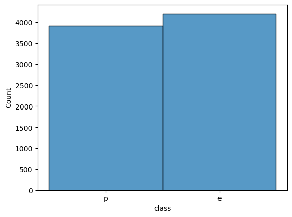

```python
sns.histplot(ds['class'])
```

```python
# Dropping the 'class' values from X
X = ds.drop(['class'],axis=1)
y = ds['class']
```

```python
X = pd.get_dummies(X)
X.head()
```

|  | cap-shape_b | cap-shape_c | cap-shape_f | cap-shape_k | cap-shape_s | cap-shape_x | cap-surface_f | cap-surface_g | cap-surface_s | cap-surface_y | ... | population_s | population_v | population_y | habitat_d | habitat_g | habitat_l | habitat_m | habitat_p | habitat_u | habitat_w |
| --- | --- | --- | --- | --- | --- | --- | --- | --- | --- | --- | --- | --- | --- | --- | --- | --- | --- | --- | --- | --- | --- |
| 0 | False | False | False | False | False | True | False | False | True | False | ... | True | False | False | False | False | False | False | False | True | False |
| 1 | False | False | False | False | False | True | False | False | True | False | ... | False | False | False | False | True | False | False | False | False | False |
| 2 | True | False | False | False | False | False | False | False | True | False | ... | False | False | False | False | False | False | True | False | False | False |
| 3 | False | False | False | False | False | True | False | False | False | True | ... | True | False | False | False | False | False | False | False | True | False |
| 4 | False | False | False | False | False | True | False | False | True | False | ... | False | False | False | False | True | False | False | False | False | False |

5 rows × 117 columns

```python
encoder = LabelEncoder()
y = encoder.fit_transform(y)
print(y)
```

```
[1 0 0 ... 0 1 0]
```

# The 80/20 split

```python
X_train, X_test, y_train, y_test = train_test_split(X, y, test_size=0.2, random_state=1)
```

```python
#Using the Decision Tree Classifier with splitting criterion as Gini impurity, the maximum depth of the tree is 3.
clf_gini = DecisionTreeClassifier(criterion='gini', max_depth=3, random_state=0)
# fit the model
clf_gini.fit(X_train, y_train)
```

```
DecisionTreeClassifier(max_depth=3, random_state=0)
```

# Plotting the tree

[output not shown]

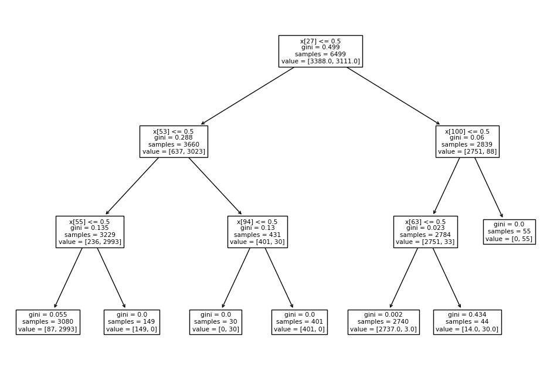

```python
#Plot the tree
plt.figure(figsize=(12,8))

tree.plot_tree(clf_gini.fit(X_train, y_train))
```

```python
#Predict the values
y_pred_gini = clf_gini.predict(X_test)
```

```python
#Predict the value using X train for accuracy comparision
y_pred_train_gini = clf_gini.predict(X_train)

y_pred_train_gini
```

```
array([0, 0, 1, ..., 1, 1, 1])
```

# Accuracy

We got a 99% accuracy for the test data and 98% accuracy for the training set data. The high accuracy tells me that the model was a good fit. The fact that the accuracies are similar is an indication that the model is not overfit or underfit. After some experimentation with the size of the test data I wasn't able to ge the accuracy to decrease much. My thoughts are that the data is so consistent and lends so well with making predictions that it is really easy to make predictions on. I can also make the assumption that the dataset is large enough that the training pool can be a wide range of sizes and still be sufficient.

```python
#Determine the accuracy score
print('Model accuracy score with criterion gini index: {0:0.4f}'. format(accuracy_score(y_test, y_pred_gini)))
#Accuracy Score for training set
print('Training-set accuracy score: {0:0.4f}'. format(accuracy_score(y_train, y_pred_train_gini)))
```

```
Model accuracy score with criterion gini index: 0.9902
Training-set accuracy score: 0.9840
```